# Project Foundations for Data Science: FoodHub Data Analysis

**Marks: 60**

### Context

The number of restaurants in New York is increasing day by day. Lots of students and busy professionals rely on those restaurants due to their hectic lifestyles. Online food delivery service is a great option for them. It provides them with good food from their favorite restaurants. A food aggregator company FoodHub offers access to multiple restaurants through a single smartphone app.

The app allows the restaurants to receive a direct online order from a customer. The app assigns a delivery person from the company to pick up the order after it is confirmed by the restaurant. The delivery person then uses the map to reach the restaurant and waits for the food package. Once the food package is handed over to the delivery person, he/she confirms the pick-up in the app and travels to the customer's location to deliver the food. The delivery person confirms the drop-off in the app after delivering the food package to the customer. The customer can rate the order in the app. The food aggregator earns money by collecting a fixed margin of the delivery order from the restaurants.

### Objective

The food aggregator company has stored the data of the different orders made by the registered customers in their online portal. They want to analyze the data to get a fair idea about the demand of different restaurants which will help them in enhancing their customer experience. Suppose you are hired as a Data Scientist in this company and the Data Science team has shared some of the key questions that need to be answered. Perform the data analysis to find answers to these questions that will help the company to improve the business.

### Data Description

The data contains the different data related to a food order. The detailed data dictionary is given below.

### Data Dictionary

- order_id: Unique ID of the order
- customer_id: ID of the customer who ordered the food
- restaurant_name: Name of the restaurant
- cuisine_type: Cuisine ordered by the customer
- cost: Cost of the order
- day_of_the_week: Indicates whether the order is placed on a weekday or weekend (The weekday is from Monday to Friday and the weekend is Saturday and Sunday)
- rating: Rating given by the customer out of 5
- food_preparation_time: Time (in minutes) taken by the restaurant to prepare the food. This is calculated by taking the difference between the timestamps of the restaurant's order confirmation and the delivery person's pick-up confirmation.
- delivery_time: Time (in minutes) taken by the delivery person to deliver the food package. This is calculated by taking the difference between the timestamps of the delivery person's pick-up confirmation and drop-off information

### Let us start by importing the required libraries

```python
# import libraries for data manipulation
import numpy as np
import pandas as pd

# import libraries for data visualization
import matplotlib.pyplot as plt
import seaborn as sns
```

### Understanding the structure of the data

```python
# read the data
df = pd.read_csv('foodhub_order.csv')
# returns the first 5 rows
df.head()
```

|  | order_id | customer_id | restaurant_name | cuisine_type | cost_of_the_order | day_of_the_week | rating | food_preparation_time | delivery_time |
| --- | --- | --- | --- | --- | --- | --- | --- | --- | --- |
| 0 | 1477147 | 337525 | Hangawi | Korean | 30.75 | Weekend | Not given | 25 | 20 |
| 1 | 1477685 | 358141 | Blue Ribbon Sushi Izakaya | Japanese | 12.08 | Weekend | Not given | 25 | 23 |
| 2 | 1477070 | 66393 | Cafe Habana | Mexican | 12.23 | Weekday | 5 | 23 | 28 |
| 3 | 1477334 | 106968 | Blue Ribbon Fried Chicken | American | 29.20 | Weekend | 3 | 25 | 15 |
| 4 | 1478249 | 76942 | Dirty Bird to Go | American | 11.59 | Weekday | 4 | 25 | 24 |

#### Observations:

- The DataFrame has 9 columns as mentioned in the Data Dictionary. Data in each row corresponds to the order placed by a customer.

### **Question 1:** How many rows and columns are present in the data? [0.5 mark]

```python
# Checking the shape of the data
df.shape
```

```
(1898, 9)
```

#### Observations:

- In our data, FoodHub, there are 1898 rows and 9 columns.

### **Question 2:** What are the datatypes of the different columns in the dataset? (The info() function can be used) [0.5 mark]

```python
# Checking the datatypes of each columns in the dataset
df.info()
```

```
<class 'pandas.core.frame.DataFrame'>
RangeIndex: 1898 entries, 0 to 1897
Data columns (total 9 columns):
 #   Column                 Non-Null Count  Dtype
---  ------                 --------------  -----
 0   order_id               1898 non-null   int64
 1   customer_id            1898 non-null   int64
 2   restaurant_name        1898 non-null   object
 3   cuisine_type           1898 non-null   object
 4   cost_of_the_order      1898 non-null   float64
 5   day_of_the_week        1898 non-null   object
 6   rating                 1898 non-null   object
 7   food_preparation_time  1898 non-null   int64
 8   delivery_time          1898 non-null   int64
dtypes: float64(1), int64(4), object(4)
memory usage: 133.6+ KB
```

#### Observations:

- There are 4 object type columns (restaurant_name, cuisine_type, day_of_the_week, and rating).
- There are 5 numerical columns. 4 are integer type (order_id, customer_id, food_preparation_time, and delivery_time) and 1 is a float type (cost_of_the_order).

### **Question 3:** Are there any missing values in the data? If yes, treat them using an appropriate method. [1 mark]

```python
# Chceking for missing values
df.isnull().sum()
```

```
order_id                 0
customer_id              0
restaurant_name          0
cuisine_type             0
cost_of_the_order        0
day_of_the_week          0
rating                   0
food_preparation_time    0
delivery_time            0
dtype: int64
```

#### Observations:

- There is no missing values in this dataset, as all columns have a return of 0.

### **Question 4:** Check the statistical summary of the data. What is the minimum, average, and maximum time it takes for food to be prepared once an order is placed? [2 marks]

```python
# Checking the statistical summary for Number variables
df.describe().T
```

|  | count | mean | std | min | 25% | 50% | 75% | max |
| --- | --- | --- | --- | --- | --- | --- | --- | --- |
| order_id | 1898.0 | 1.477496e+06 | 548.049724 | 1476547.00 | 1477021.25 | 1477495.50 | 1.477970e+06 | 1478444.00 |
| customer_id | 1898.0 | 1.711685e+05 | 113698.139743 | 1311.00 | 77787.75 | 128600.00 | 2.705250e+05 | 405334.00 |
| cost_of_the_order | 1898.0 | 1.649885e+01 | 7.483812 | 4.47 | 12.08 | 14.14 | 2.229750e+01 | 35.41 |
| food_preparation_time | 1898.0 | 2.737197e+01 | 4.632481 | 20.00 | 23.00 | 27.00 | 3.100000e+01 | 35.00 |
| delivery_time | 1898.0 | 2.416175e+01 | 4.972637 | 15.00 | 20.00 | 25.00 | 2.800000e+01 | 33.00 |

#### Observations:

- Even though, order_id and customer_id are numerical categories, they are just identifiers for each order. Therefore, there is no nead to take into consideration their quartile, mean, and stardard deviation.
- Information on food prepartion time:
  - Minumum: 20 minutes
  - Average: 27.3 minutes
  - Maximum: 35 minutes
- With this function, I can get the same information for cost of the order and delivery time.

### **Question 5:** How many orders are not rated? [1 mark]

```python
# Checking how many orders weren't rated
df['rating'].value_counts()
```

```
rating
Not given    736
5            588
4            386
3            188
Name: count, dtype: int64
```

#### Observations:

- There are 736 orders that are not rated out of 1898 orders placed on the FoodHub app.

### Exploratory Data Analysis (EDA)

### **Question 6:** Explore all the variables and provide observations on their distributions. (Generally, histograms, boxplots, countplots, etc. are used for univariate exploration.) [9 marks]

A. Order ID (order_id)

```python
# Checking the total number of unique values in the column order_id
df['order_id'].nunique()
```

```
1898
```

- Each order are unique, there is 1898 orders placed. Is column is also just an identifier for each order placed.
- This confirms the dataset intergrity.

B. Customer ID (customer_id)

```python
# Checking the total number of unique values in the column customer_id
df['customer_id'].nunique()
```

```
1200
```

- The customer ID column is also a variable to identify each customer that is ordering through the app.
- There are 1200 customers who order food, indicating some customers have ordered more than once through this app.

C. Restaurant name (restaurant_name)

```python
# Checking the total number of unique values in the column restaurant_name
df['restaurant_name'].nunique()
```

```
178
```

- There are 178 different restaurants that uses this FoodHub app.

D. Cuisine Type (cuisine_type)

```python
# Checking the total number of unique values in the column cuisine_type
df['cuisine_type'].nunique()
```

```
14
```

- There are 14 different cuisine types.

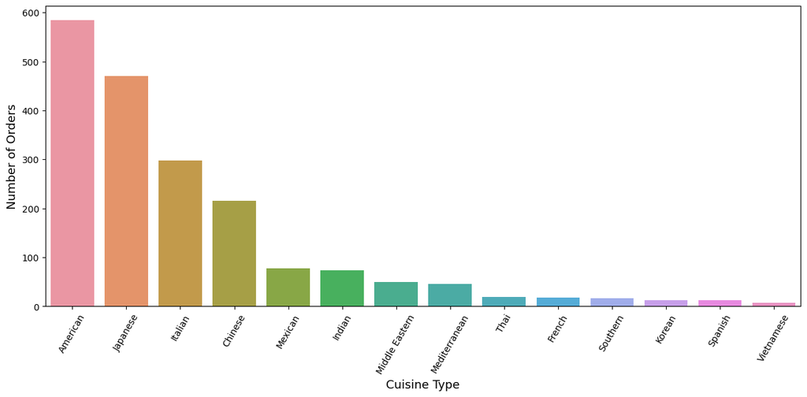

```python
# Creating a bar graph to analyze the different cuisine
plt.figure(figsize=(15, 6))
sns.countplot(data=df, x='cuisine_type', order=df['cuisine_type'].value_counts().index)   # adding order to be able to get the value counts in ascending order
plt.xlabel('Cuisine Type', size=13)
plt.ylabel('Number of Orders', size=13)
plt.xticks(rotation=60)
plt.show()
```

Let's see the percentage of the 4 top cuisines

```python
# Creating a 4 seperate new dataframes only including the orders of the 4 top cuisine types seperately
df_American = df[df['cuisine_type'] == 'American']
df_Japanese = df[df['cuisine_type'] == 'Japanese']
df_Italian = df[df['cuisine_type'] == 'Italian']
df_Chinese = df[df['cuisine_type'] == 'Chinese']

# Getting the percentage of order of the top 4 cuisine types seperately
American = (df_American.shape[0] / df.shape[0]) * 100
print('The percentage of American food order is:', round(American, 2))
Japanese = (df_Japanese.shape[0] / df.shape[0]) * 100
print('The percentage of Japanese food order is:', round(Japanese, 2))
Italian = (df_Italian.shape[0] / df.shape[0]) * 100
print('The percentage of Italian food order is:', round(Italian, 2))
Chinese = (df_Chinese.shape[0] / df.shape[0]) * 100
print('The percentage of Chinese food order is:', round(Chinese, 2))

# Getting the percentage of order for the top 4 cuisine types combined
print('The percentage of the 4 most popular cuisine combined is:', round(Japanese+American+Italian+Chinese, 2))
```

```
The percentage of American food order is: 30.77
The percentage of Japanese food order is: 24.76
The percentage of Italian food order is: 15.7
The percentage of Chinese food order is: 11.33
The percentage of the 4 most popular cuisine combined is: 82.56
```

- Around 82% of the orders are Japanese, American, Italian, and Chinese cuisines, which are the 4 most popular cuisines chosen.
- The most popular cuisine is American with 30.8%, then Japanese (24.8%), Italian (15.8%), and Chinese (11.3%).

E. Cost of the order (cost_of_the_order)

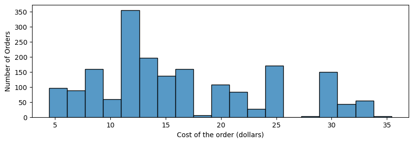

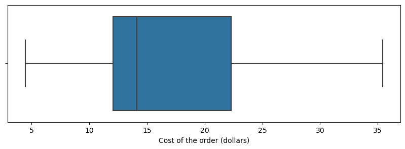

```python
# Creating a histogram
plt.figure(figsize=(10, 3))
sns.histplot(data=df, x='cost_of_the_order')
plt.xlabel('Cost of the order (dollars)', size=10)
plt.ylabel('Number of Orders', size=10)
plt.show()

# Creating a box plot to see the distribution.
plt.figure(figsize=(10, 3))
sns.boxplot(data=df, x='cost_of_the_order')
plt.xlabel('Cost of the order (dollars)', size=10)
plt.show()
```

- The histogram shows that orders through FoodHub are between around 4 and 36 dollars.
- It also seems that the cost of most orders is bewteen 11 and 13 dollars with a order count close to 350.
- The boxplot indicated that there are no outliers in the dataset.
- It also shows us that 50% of the orders cost between around 12 and 23 dollars.
- The median cost is around 14 dollars.
- In addition, this distribution is positively skewed (skewed right) as the average order cost is greater than the median.

F. Day of the Week (day_of_the_week)

```python
# Checking the total number of unique values in the column day_of_the_week
df['day_of_the_week'].nunique()
```

```
2
```

- There are 2 different outcomes for the day of the week.

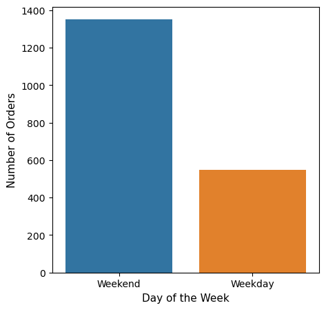

```python
# lets check what are those two outcomes with a bar graph
plt.figure(figsize=(5,5))
sns.countplot(data=df, x='day_of_the_week')
plt.xlabel('Day of the Week', size=11)
plt.ylabel('Number of Orders', size=11)
plt.show()
```

- The day of the week outcomes are weekend and weekday of when the order was placed during the week.
- Most orders are during the weekends, with more than double of the orders in 2 days compared to the 5 days of the week.

G. Rating

```python
# Checking the total number of unique values in the column rating
df['rating'].nunique()
```

```
4
```

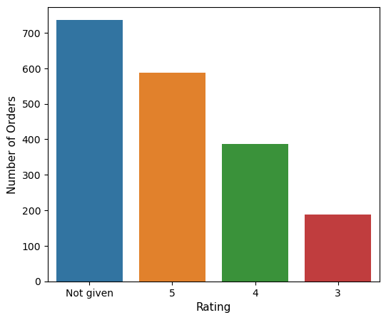

```python
# lets check what are those four outcomes with a bar graph
plt.figure(figsize=(6,5))
sns.countplot(data=df, x='rating', order=df['rating'].value_counts().index)
plt.xlabel('Rating', size=11)
plt.ylabel('Number of Orders', size=11)
plt.show()
```

- This bar graph indicates most orders are not given a rating, followed by a 5 star rating given to almost 600 orders.
- The lowest rating is a 3 star which was given to around 200 orders.

H. Food Preparation Time (food_preparation_time)

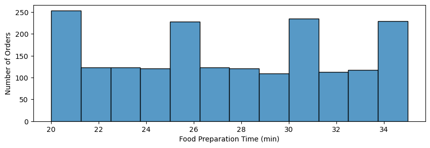

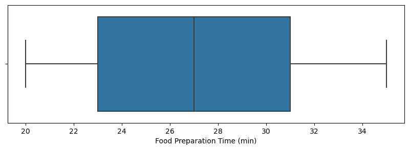

```python
# Creating a histogram
plt.figure(figsize=(10, 3))
sns.histplot(data=df,x='food_preparation_time')
plt.xlabel('Food Preparation Time (min)', size=10)
plt.ylabel('Number of Orders', size=10)
plt.show()

# Creating a box plot to see the distribution.
plt.figure(figsize=(10, 3))
sns.boxplot(data=df, x='food_preparation_time')
plt.xlabel('Food Preparation Time (min)', size=10)
plt.show()
```

- This boxplot shows no outlers for this variable in this dataset.
- The median (27 minutes) is almost equal to the mean (27.3 minutes) which indicates that this varaible has a distribution that is nearly symmetrical.
- This nearly symmetrical distribution also means that the food preparation time is closely evenly distributed between 20 and 35 minutes.
- In addition, 50% of the food preparatin time is between around 23 and 31 minutes.

I. Delivery Time (delivery_time)

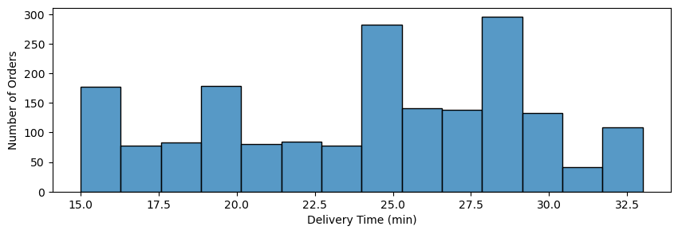

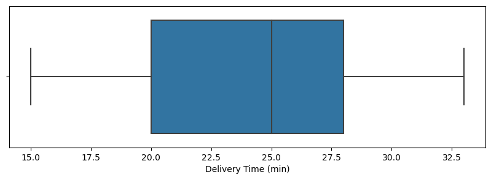

```python
# Creating a histogram
plt.figure(figsize=(10, 3))
sns.histplot(data=df, x='delivery_time')
plt.xlabel('Delivery Time (min)', size=10)
plt.ylabel('Number of Orders', size=10)
plt.show()

# lets check the distribution with a bar graph
plt.figure(figsize=(10, 3))
sns.boxplot(data=df, x='delivery_time')
plt.xlabel('Delivery Time (min)', size=10)
plt.show()
```

- This boxplot shows no outlers for this variable in this dataset.
- The minimum delivery time is 15 minutes and the maximum is 33 minutes. The median delivery time is 25 minutes.
- Eventhough, 50% of the delivery time are between 20 and 28 minutes, most of the orders are delivered between 24 and 30 minutes, which is shown by the histogram.
- The distribution is slightly negativly skewed (skewed left).

### **Question 7**: Which are the top 5 restaurants in terms of the number of orders received? [1 mark]

```python
# Getting top 5 restaurants with highest number of orders received
df['restaurant_name'].value_counts().head(5)
```

```
restaurant_name
Shake Shack                  219
The Meatball Shop            132
Blue Ribbon Sushi            119
Blue Ribbon Fried Chicken     96
Parm                          68
Name: count, dtype: int64
```

#### Observations:

- The top five restaurant with the highest number of orders received are Shake Shack, The Meatball Shop, Blue Ribbon Sushi, Blue Ribbon Fried Chicken, and Parm.

### **Question 8**: Which is the most popular cuisine on weekends? [1 mark]

```python
# Creating a new dataframe only including weekends orders
df_weekend = df[df['day_of_the_week'] == 'Weekend']

# Getting the most popular cuisine on weekends
df_weekend['cuisine_type'].value_counts()
```

```
cuisine_type
American          415
Japanese          335
Italian           207
Chinese           163
Mexican            53
Indian             49
Mediterranean      32
Middle Eastern     32
Thai               15
French             13
Korean             11
Southern           11
Spanish            11
Vietnamese          4
Name: count, dtype: int64
```

#### Observations:

- The most popular cuisine on the weekends is American cuisine.

### **Question 9**: What percentage of the orders cost more than 20 dollars? [2 marks]

```python
# Getting orders that cost most 20 dollars
df_greater_than_20 = df[df['cost_of_the_order'] > 20]

# Seeing the number of orders costing more than 20 dollars
print('The number of total orders costing more than 20 dollars is:', df_greater_than_20.shape[0])

# Getting the percentage of order costing more than 20 dollars
percentage = (df_greater_than_20.shape[0] / df.shape[0]) * 100
print("The percentage of orders that cost more than 20 dollars is:", round(percentage, 2), '%')
```

```
The number of total orders costing more than 20 dollars is: 555
The percentage of orders that cost more than 20 dollars is: 29.24 %
```

#### Observations:

- Out of the 1898 orders, only 555 orders cost more than 20 dollars which correspond to 29.24% of the orders, more than a quarter.

### **Question 10**: What is the mean order delivery time? [1 mark]

```python
# Chekcing the mean order delivery time
print('The mean order delivery time is', round(df['delivery_time'].mean(), 2), 'minutes')
```

```
The mean order delivery time is 24.16 minutes
```

#### Observations:

- The average time of an order delivery is around 24 minutes.

### **Question 11:** The company has decided to give 20% discount vouchers to the top 3 most frequent customers. Find the IDs of these customers and the number of orders they placed. [1 mark]

```python
# Finding the top 3 most frequent customers id with how many orders they placed
df['customer_id'].value_counts().head(3)
```

```
customer_id
52832    13
47440    10
83287     9
Name: count, dtype: int64
```

### **Question 12**: Perform a multivariate analysis to explore relationships between the important variables in the dataset. (It is a good idea to explore relations between numerical variables as well as relations between numerical and categorical variables) [10 marks]

A. Cuisine vs Cost of the order

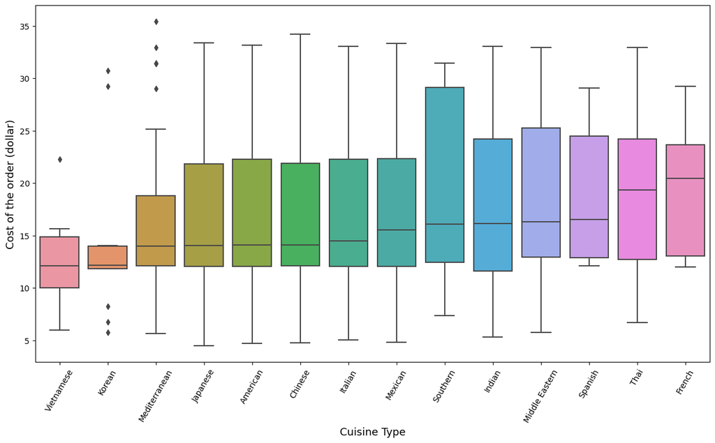

```python
# Ordering the cuisine types by median values
order_A = df.groupby('cuisine_type')['cost_of_the_order'].median().sort_values().index

# Relationship between cost of the order and cuisine type
plt.figure(figsize=(15, 8))
sns.boxplot(data=df, x='cuisine_type', y='cost_of_the_order', order=order_A)
plt.xlabel('Cuisine Type', size=13)
plt.ylabel('Cost of the order (dollar)', size=13)
plt.xticks(rotation=60)
plt.show()
```

- Vietnamese and Korean cuisines have the lowest order costs compared to other cuisines. These two cuisines also have their order costs condensed.
- French and Thai cuisine are the most expensive cuisines median. However, French cuisine has the most expensive order cost with a median around 20 dollars.
- We can also see that 4 cuisines have similar boxplots indicating that their quartile costs are similar. These cuisines are Japanese, American, Italian, and Chinese.
- Outliers are present in this graph for Korean, Mediterranean, and Vietnamese cuisines. This indicated that they had some extreme order costs.

```python
# Getting the average order cost of each type of cuisine
cuisine_cost_mean = df.groupby('cuisine_type')['cost_of_the_order'].mean().sort_values(ascending = False).reset_index().copy()
# Renaming the columns in this dataset
cuisine_cost_mean.columns = ['Cuisine Type', 'Order Cost Mean']
cuisine_cost_mean
```

|  | Cuisine Type | Order Cost Mean |
| --- | --- | --- |
| 0 | French | 19.793889 |
| 1 | Southern | 19.300588 |
| 2 | Thai | 19.207895 |
| 3 | Spanish | 18.994167 |
| 4 | Middle Eastern | 18.820612 |
| 5 | Mexican | 16.933117 |
| 6 | Indian | 16.919726 |
| 7 | Italian | 16.418691 |
| 8 | American | 16.319829 |
| 9 | Chinese | 16.305209 |
| 10 | Japanese | 16.304532 |
| 11 | Mediterranean | 15.474783 |
| 12 | Korean | 14.001538 |
| 13 | Vietnamese | 12.882857 |

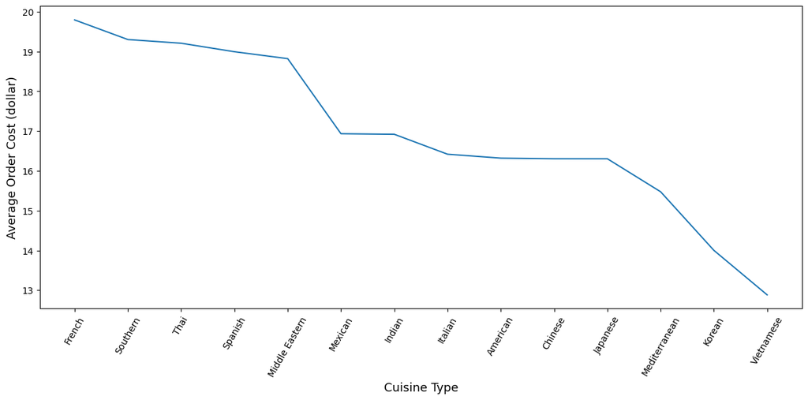

```python
# Plotting the relationship between each cuisine type and their order cost average
plt.figure(figsize=(15, 6))
sns.lineplot(data=cuisine_cost_mean, x='Cuisine Type', y='Order Cost Mean', sort=False)
plt.xlabel('Cuisine Type', size=13)
plt.ylabel('Average Order Cost (dollar)', size=13)
plt.xticks(rotation=60)
plt.show()
```

- The most expensive order cost mean is French cuisine, then Southern cuisine.
- Between the most expensive cuisine cost mean and the cheapest, there is a different of around 7 dollars.

B. Cuisine vs Food Preparation Time

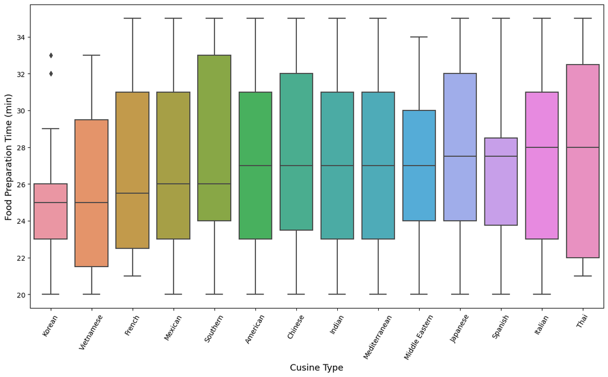

```python
# Ordering the cuisine types by median values
order_B = df.groupby('cuisine_type')['food_preparation_time'].median().sort_values().index

# Relationship between cuisine type and food preparation time
plt.figure(figsize=(15, 8))
sns.boxplot(data=df, x='cuisine_type', y='food_preparation_time', order=order_B)
plt.xlabel('Cusine Type', size=13)
plt.ylabel('Food Preparation Time (min)', size=13)
plt.xticks(rotation=60)
plt.show()
```

- The first observation is that the food preparation time is consistent for most of the cuisines. The median of all 14 cuisines are between 25 and 28 minutes.
- Even though, Korean cuisine has two outliers present, it also has the most consende food preparation time, which is the cuisine that takes the least time to be prepared.

```python
# Getting the average food preparation time for each cuisine type
preparation_mean = df.groupby('cuisine_type')['food_preparation_time'].mean().sort_values(ascending = False).reset_index().copy()
# Renaming the columns in this dataset
preparation_mean.columns = ['Cuisine Type', 'Mean Food Preparation Time']
preparation_mean
```

|  | Cuisine Type | Mean Food Preparation Time |
| --- | --- | --- |
| 0 | Southern | 27.588235 |
| 1 | Chinese | 27.511628 |
| 2 | Japanese | 27.510638 |
| 3 | Italian | 27.483221 |
| 4 | American | 27.440068 |
| 5 | Thai | 27.315789 |
| 6 | Indian | 27.109589 |
| 7 | Mediterranean | 27.000000 |
| 8 | Spanish | 26.916667 |
| 9 | French | 26.888889 |
| 10 | Mexican | 26.727273 |
| 11 | Middle Eastern | 26.673469 |
| 12 | Vietnamese | 25.714286 |
| 13 | Korean | 25.461538 |

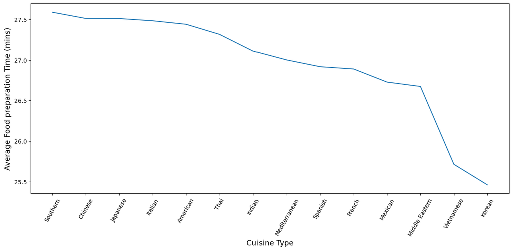

```python
# Plotting the relationship between each cuisine type and their average food preparation time
plt.figure(figsize=(15, 6))
sns.lineplot(data=preparation_mean, x='Cuisine Type', y='Mean Food Preparation Time', sort=False)
plt.xlabel('Cuisine Type', size=13)
plt.ylabel('Average Food preparation Time (mins)', size=13)
plt.xticks(rotation=60)
plt.show()
```

- Southern cuisine has the highest food preparation time mean with almost 28 minutes.
- Korean cuisine has the lowest food preparation time mean with almost 26 minutes.

C. Mean Food Preparation Time vs Mean cuisine order cost

```python
# Creating a new dataframe 'df_mean' that would be merging preparation_mean & cuisine_cost_mean
df_mean = pd.merge(preparation_mean, cuisine_cost_mean, how='outer', on = 'Cuisine Type')
df_mean.head()
```

|  | Cuisine Type | Mean Food Preparation Time | Order Cost Mean |
| --- | --- | --- | --- |
| 0 | Southern | 27.588235 | 19.300588 |
| 1 | Chinese | 27.511628 | 16.305209 |
| 2 | Japanese | 27.510638 | 16.304532 |
| 3 | Italian | 27.483221 | 16.418691 |
| 4 | American | 27.440068 | 16.319829 |

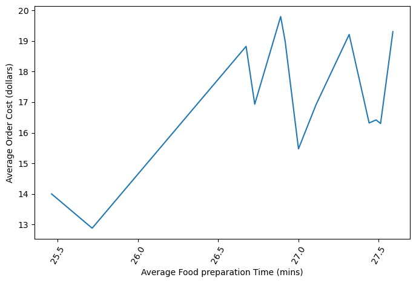

```python
plt.figure(figsize=(8, 5))
sns.lineplot(data=df_mean, x='Mean Food Preparation Time', y='Order Cost Mean', sort=False)
plt.xlabel('Average Food preparation Time (mins)', size=10)
plt.ylabel('Average Order Cost (dollars)', size=10)
plt.xticks(rotation=60)
plt.show()
```

- It seems there is a correlation between average food preparation time and the average cost of the order.
- Let's check the correlation.

```python
# Checking the correlation between the average food preparation time and the average cost of the order
corr_avg = ['Mean Food Preparation Time', 'Order Cost Mean']
corr_mean = df_mean[corr_avg].corr()
corr_mean
```

|  | Mean Food Preparation Time | Order Cost Mean |
| --- | --- | --- |
| Mean Food Preparation Time | 1.000000 | 0.545067 |
| Order Cost Mean | 0.545067 | 1.000000 |

- There is a moderate positive correlation between the average food preparation time and the average cost of the order.

D. Cuisine vs Delivery Time

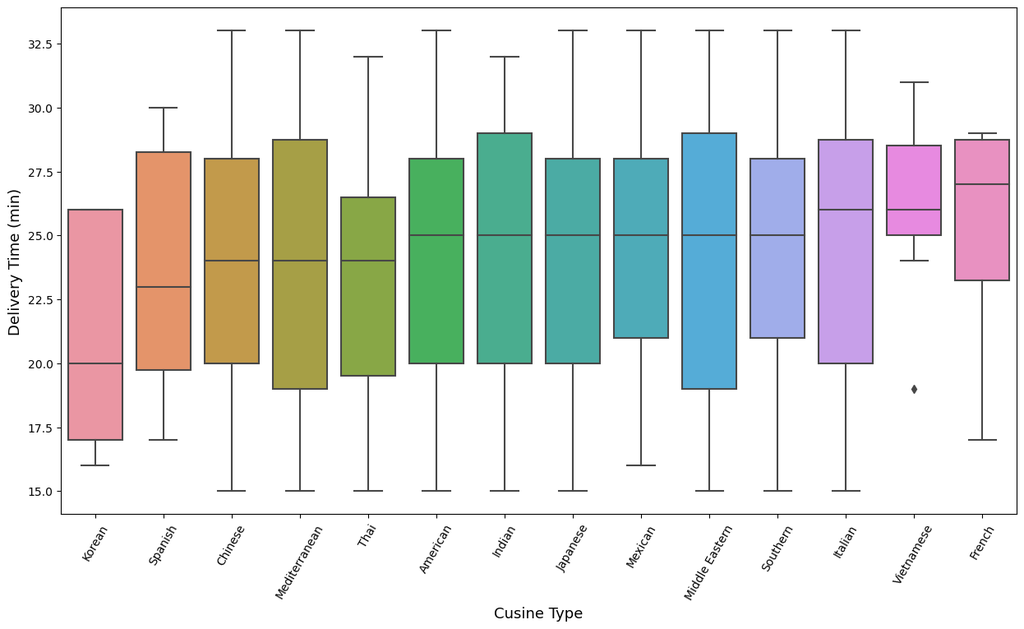

```python
# Ordering the cuisine types by median values
order_D = df.groupby('cuisine_type')['delivery_time'].median().sort_values().index

# Relationship between cuisine type and delivery time
plt.figure(figsize=(15, 8))
sns.boxplot(data=df, x='cuisine_type', y='delivery_time', order=order_D)
plt.xlabel('Cusine Type', size=13)
plt.ylabel('Delivery Time (min)', size=13)
plt.xticks(rotation=60)
plt.show()
```

E. Delivery Time vs Day of the Week

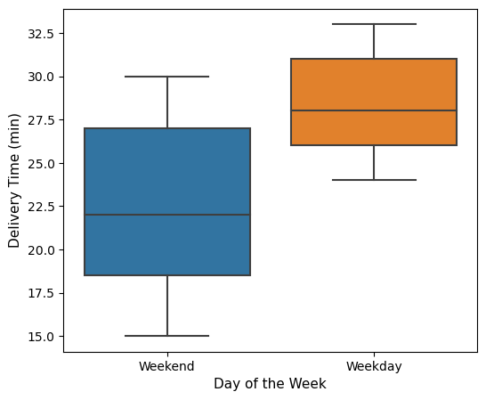

```python
# Relationship between delivery time and day of the week
plt.figure(figsize=(6, 5))
sns.boxplot(data=df, x='day_of_the_week', y='delivery_time')
plt.xlabel('Day of the Week', size=11)
plt.ylabel('Delivery Time (min)', size=11)
plt.show()
```

- Weekday median is around 28 minutes while the 3rd quartile of weekend is around 27 minutes. Weekday lowest delivery time is around 24 minutes.
- The weekend median is around 22 minutes. The quickest delivery times are during the weekend at 15 minutes.
- Therefore, delivery time is signaficaly longer during the week days.
- Speculation: The time difference could be correlated to higher traffic during week days or less delivery persons by lower demands.

F. Delivery time vs Rating

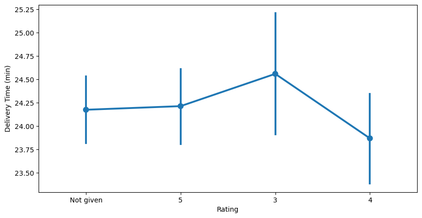

```python
# Relationship between delivery time and rating
plt.figure(figsize=(10, 5))
sns.pointplot(data = df, x = 'rating', y = 'delivery_time')
plt.xlabel('Rating', size=10)
plt.ylabel('Delivery Time (min)', size=10)
plt.show()
```

- The lowest rating on the FoodHub app is are 3 and it seems that it is due to a higher delivery time.
- The lowest delivery times have a 4 star rating.
- So, it is possible that delivery time plays a role in low-rating.

G. Rating vs Food preparation time

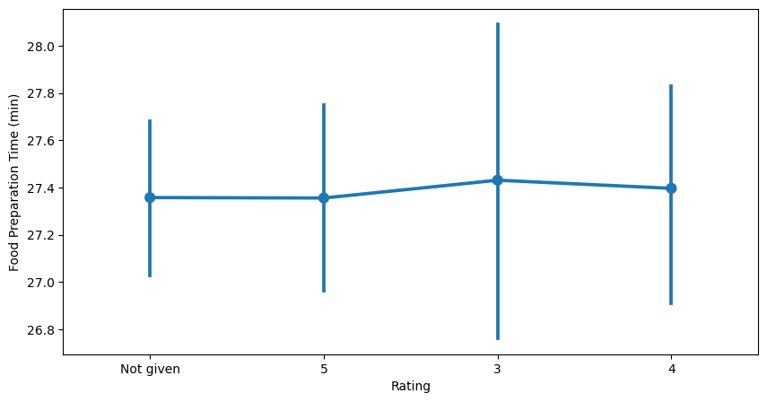

```python
# Relationship between rating and food preparation time
plt.figure(figsize=(10, 5))
sns.pointplot(data = df, x = 'rating', y = 'food_preparation_time')
plt.xlabel('Rating', size=10)
plt.ylabel('Food Preparation Time (min)', size=10)
plt.show()
```

- The lowest rating on the FoodHub app is are 3 and it has a slightly higher food preparation time.
- However, the food preparation time seems to have little influence on the rating as the preparation time for the rating are around 27.4 minutes.

H. Rating vs Cost of the Order

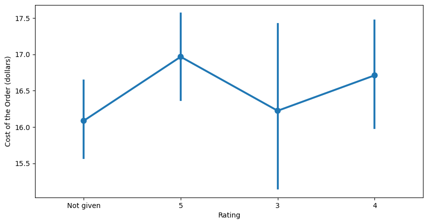

```python
# Relationship between rating and cost of the order
plt.figure(figsize=(10, 5))
sns.pointplot(data = df, x = 'rating', y = 'cost_of_the_order')
plt.xlabel('Rating', size=10)
plt.ylabel('Cost of the Order (dollars)', size=10)
plt.show()
```

- The higher the cost of the order is, the higher the rating is.
- The lowest order costs seems to not been rated.
- However, the true value of the order cost varie less than 1 dollars in regards to the rating, meaning that cost of the order may not play a role in ratings.

I. Cost of the order vs Restaurant name

```python
df.groupby(['restaurant_name'])['cost_of_the_order'].sum().sort_values(ascending = False).head(14)
```

```
restaurant_name
Shake Shack                      3579.53
The Meatball Shop                2145.21
Blue Ribbon Sushi                1903.95
Blue Ribbon Fried Chicken        1662.29
Parm                             1112.76
RedFarm Broadway                  965.13
RedFarm Hudson                    921.21
TAO                               834.50
Han Dynasty                       755.29
Blue Ribbon Sushi Bar & Grill     666.62
Rubirosa                          660.45
Sushi of Gari 46                  640.87
Nobu Next Door                    623.67
Five Guys Burgers and Fries       506.47
Name: cost_of_the_order, dtype: float64
```

- This code allows us to see the revenue generated by the restaurant thanks to the orders through the FoodHub app. Shake Shack restaurant has the hightest revenue.
- The revenues of the top five restaurant are the same top five restaurant with the highest number of order received.

J. Correlation among variable (multivariate)

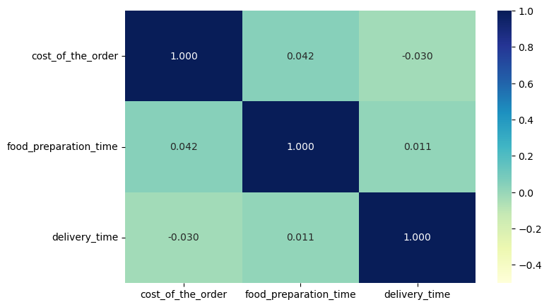

```python
# Extracting the variables wanted
corr=['cost_of_the_order', 'food_preparation_time', 'delivery_time']

# Plotting a heatmap with the correlation
plt.figure(figsize=(8, 5))
sns.heatmap(df[corr].corr(), annot=True, vmin=-0.5, vmax=1, fmt=".3f", cmap='YlGnBu')
plt.show()
```

- The heatmap shows that there are no correlation between these three variables. The highest correlation (0.042) seen is between the food preparation time and the cost of the order.

### **Question 13:** The company wants to provide a promotional offer in the advertisement of the restaurants. The condition to get the offer is that the restaurants must have a rating count of more than 50 and the average rating should be greater than 4. Find the restaurants fulfilling the criteria to get the promotional offer. [3 marks]

```python
# Creating a copy dataset without the rows that have 'not given' rating
df_rating = df[df['rating'] != 'Not given'].copy()

# Converting rating column from object to integer
df_rating['rating'] = df_rating['rating'].astype('int')
```

```python
# Creating a dataframe 'rating_count' containing the restaurant names with their rating counts
df_rating_count = df_rating.groupby(['restaurant_name'])['rating'].count().sort_values(ascending = False).reset_index().copy()

# Renaming the columns in this dataset
df_rating_count.columns = ['restaurant_name', 'rating_count']

df_rating_count.head()
```

|  | restaurant_name | rating_count |
| --- | --- | --- |
| 0 | Shake Shack | 133 |
| 1 | The Meatball Shop | 84 |
| 2 | Blue Ribbon Sushi | 73 |
| 3 | Blue Ribbon Fried Chicken | 64 |
| 4 | RedFarm Broadway | 41 |

```python
# Creating a dataframe 'rating_mean' containing the restaurant names with their rating mean
df_rating_mean = df_rating.groupby('restaurant_name')['rating'].mean().sort_values(ascending = False).reset_index()

# Renaming the columns in this dataset
df_rating_mean.columns = ['restaurant_name', 'rating_mean']

df_rating_mean.head()
```

|  | restaurant_name | rating_mean |
| --- | --- | --- |
| 0 | 'wichcraft | 5.0 |
| 1 | Ravagh Persian Grill | 5.0 |
| 2 | Chola Eclectic Indian Cuisine | 5.0 |
| 3 | Chote Nawab | 5.0 |
| 4 | Junoon | 5.0 |

```python
# Creating a new dataframe 'df_condition' that would be merging df_rating_count & df_rating_mean
df_condition = pd.merge(df_rating_count, df_rating_mean, how='outer', on = 'restaurant_name')
df_condition.head()
```

|  | restaurant_name | rating_count | rating_mean |
| --- | --- | --- | --- |
| 0 | Shake Shack | 133 | 4.278195 |
| 1 | The Meatball Shop | 84 | 4.511905 |
| 2 | Blue Ribbon Sushi | 73 | 4.219178 |
| 3 | Blue Ribbon Fried Chicken | 64 | 4.328125 |
| 4 | RedFarm Broadway | 41 | 4.243902 |

```python
# Creating a dataframe 'df_offer' that would show the restaurant names selected with their rating count & mean
df_offer = df_condition[(df_condition['rating_count'] > 50) & (df_condition['rating_mean'] > 4)]
df_offer
```

|  | restaurant_name | rating_count | rating_mean |
| --- | --- | --- | --- |
| 0 | Shake Shack | 133 | 4.278195 |
| 1 | The Meatball Shop | 84 | 4.511905 |
| 2 | Blue Ribbon Sushi | 73 | 4.219178 |
| 3 | Blue Ribbon Fried Chicken | 64 | 4.328125 |

#### Observations:

- Only four restaurants fulfilled the criteria to get the promotional offer, which were to have a rating count greater than 50 and a rating mean greater than 4. The four restaurants receiving the promotional are Shake Shack, The Meatball Shop, Blue Ribbon Sushi, and Blue Ribbion Fried Chicken.
- These four restaurants are also the same, respectively, four restaurants with the highest number of orders received and the highest revenue generated.

### **Question 14:** The company charges the restaurant 25% on the orders having cost greater than 20 dollars and 15% on the orders having cost greater than 5 dollars. Find the net revenue generated by the company across all orders. [3 marks]

```python
# Creating a function (calculate_rev) to get the company's revenue on each order thanks to a loop
def calculate_rev(x):
    if x > 20:              # Order(x) greater than 20 dollars
        return x * 0.25     # Multiply the order cost by 25 %
    elif x > 5:             # Order(x) greater than 5 dollars
        return x * 0.15     # Multiply the order cost by 15 %
    else:
        return x * 0        # Multiply the order cost by 0 if the order cost is lower than 5 dollars.

# Creating a new column 'revenue' in our dataframe (df) with the company's revenue corresponding each order
df['revenue'] = df['cost_of_the_order'].apply(calculate_rev)
df.head()
```

|  | order_id | customer_id | restaurant_name | cuisine_type | cost_of_the_order | day_of_the_week | rating | food_preparation_time | delivery_time | revenue |
| --- | --- | --- | --- | --- | --- | --- | --- | --- | --- | --- |
| 0 | 1477147 | 337525 | Hangawi | Korean | 30.75 | Weekend | Not given | 25 | 20 | 7.6875 |
| 1 | 1477685 | 358141 | Blue Ribbon Sushi Izakaya | Japanese | 12.08 | Weekend | Not given | 25 | 23 | 1.8120 |
| 2 | 1477070 | 66393 | Cafe Habana | Mexican | 12.23 | Weekday | 5 | 23 | 28 | 1.8345 |
| 3 | 1477334 | 106968 | Blue Ribbon Fried Chicken | American | 29.20 | Weekend | 3 | 25 | 15 | 7.3000 |
| 4 | 1478249 | 76942 | Dirty Bird to Go | American | 11.59 | Weekday | 4 | 25 | 24 | 1.7385 |

```python
# Calculating the company's total net revenue
total_rev = df['revenue'].sum()
print("The company's total net revenue is", round(total_rev, 2), "dollars" )
```

```
The company's total net revenue is 6166.3 dollars
```

#### Observations:

- For 1898 orders, FoodHub company has made a total net revenue of 6166.3 dollars.
- FoodHub average 3.2 dollars revenue on each order.

### **Question 15:** The company wants to analyze the total time required to deliver the food. What percentage of orders take more than 60 minutes to get delivered from the time the order is placed? (The food has to be prepared and then delivered.) [2 marks]

```python
# Creating a new column 'total_time' the total time required to deliver the food (preparation + delivery)
df['total_time'] = df['food_preparation_time'] + df['delivery_time']
df.head()
```

|  | order_id | customer_id | restaurant_name | cuisine_type | cost_of_the_order | day_of_the_week | rating | food_preparation_time | delivery_time | revenue | total_time |
| --- | --- | --- | --- | --- | --- | --- | --- | --- | --- | --- | --- |
| 0 | 1477147 | 337525 | Hangawi | Korean | 30.75 | Weekend | Not given | 25 | 20 | 7.6875 | 45 |
| 1 | 1477685 | 358141 | Blue Ribbon Sushi Izakaya | Japanese | 12.08 | Weekend | Not given | 25 | 23 | 1.8120 | 48 |
| 2 | 1477070 | 66393 | Cafe Habana | Mexican | 12.23 | Weekday | 5 | 23 | 28 | 1.8345 | 51 |
| 3 | 1477334 | 106968 | Blue Ribbon Fried Chicken | American | 29.20 | Weekend | 3 | 25 | 15 | 7.3000 | 40 |
| 4 | 1478249 | 76942 | Dirty Bird to Go | American | 11.59 | Weekday | 4 | 25 | 24 | 1.7385 | 49 |

```python
# Filtering the orders taking more than 60 mins to be delivered
df_greater_than_60 = df[df['total_time'] > 60]

# Seeing the number of orders taking more than 60 mins to be delivered
print('The number of total orders taking more than 60 mins to be delivered is:', df_greater_than_60.shape[0])

# Getting the percentage of order taking more than 60 mins to be delivered
percentage = (df_greater_than_60.shape[0] / df.shape[0]) * 100
print("The percentage of orders taking more than 60 mins to be delivered:", round(percentage, 2), '%')
```

```
The number of total orders taking more than 60 mins to be delivered is: 200
The percentage of orders taking more than 60 mins to be delivered: 10.54 %
```

#### Observations:

- Out of the 1898 orders through FoodHub, 200 of them take more than 60 minutes for the food to be delivered from the moment the order is placed.
- These 200 orders represent 10.54% of the orders on the app.

### **Question 16:** The company wants to analyze the delivery time of the orders on weekdays and weekends. How does the mean delivery time vary during weekdays and weekends? [2 marks]

```python
# Calculating the mean delivery time on weekdays
delivery_weekday = df[df['day_of_the_week']=='Weekday']['delivery_time'].mean()
print('The mean delivery time during the weekdays is', round(delivery_weekday, 2), 'minutes')

# Calculating the mean delivery time on weekends
delivery_weekend = df[df['day_of_the_week']=='Weekend']['delivery_time'].mean()
print('The mean delivery time during the weekends is', round(delivery_weekend, 2), 'minutes')
```

```
The mean delivery time during the weekdays is 28.34 minutes
The mean delivery time during the weekends is 22.47 minutes
```

#### Observations:

- During the weekends, the delivery time is faster by almost 6 minutes.
- The time difference could be correlated to lower traffic during weekends or more delivery persons by higher demands.

### Recommendations:

- FoodHub company should look in the reason behind the high amount of not given rating as customers rating is an important factor not only to gauge customer statisfaction but also for other customers to chose which restaurant to order from. The rating page on the app probably needs to be modifed and upgraded to get a higher rating number.
- As the weekdays delivery times are higher, the company should maybe change their mean of transportation to motobikes or bikecycles to help reduce time being stuck in traffic.
- The company should look into employing more delivery persons during weekdays to reduce the delivery time to see if it has an impact on total revenues. In other words, is there a correlation between the reduction of the delivery time and the number of orders. Are the orders going to increase during weekdays because of a lower delivery time in order to get a high revenue?
- In addtion to changing their mean of transportation and increasing employement during weendays, FoodHUb could also implement a maximum delivery time and offer a reward or bonus to all punctual delivery persons. This factor could also have a positive effect on delivery time.
- FoodHub should also provide promotional offers the top 3 rated-restaurants and the top 3 restaurant with the highest order count. These offers could increse the number of orders received by those restaurants and it would be a beneficial gain for both businesses.
- As the most popular cuisines are American, Japanese, Italian, and Chinese, Foodhub could recruite more restaurants with these types of cuisines to increase orders and revenue.
- If, this company would like to keep some of the lowest cuisine type such as Korean or Vietnamese, they could create advertisement/promote on those cuisines to encourage customers to order. They could also offer some type of discounts for those cuisines in the begening to increase rating on those types of cuisine.
- Since FoodHub is getting a percentage of the order cost, they could increase the number of restaurant in French and Southern cuisine as they have a heiger mean order cost.